# Nieklasyczne metody statystyki

Regularyzacja

Julia Deptulska

2024-12-23

To laboratorium na temat Regresji grzbietowej (Ridge Regression - RR) i Lasso w R pochodzi ze stron 251-255 książki “Introduction to Statistical Learning with Applications in R” autorstwa Garetha Jamesa, Danieli Witten, Trevora Hastie i Roberta Tibshirani. Zostało ono ponownie zaimplementowane jesienią 2016 roku w formacie `tidyverse` przez Amelię McNamarę i R. Jordana Crousera w Smith College.

W tym tygodniu omówimy dwie alternatywne formy regresji liniowej zwane **regresją grzbietową** i **regresją LASSO**. Te dwie metody są przykładami metod **regularyzacji** lub **zmniejszania**, w których zachęca się do tego, aby parametry modelu były małe.

# Regresja Grzbietowa i Lasso

Wykorzystamy pakiet `glmnet` w celu przeprowadzenia regresji ridge i lasso. Główną funkcją w tym pakiecie jest `glmnet()`, która może być użyta do dopasowania modeli regresji grzbietowej, modeli lasso i innych.

Funkcja ta ma nieco inną składnię niż inne funkcje dopasowujące modele, z którymi zetknęliśmy się do tej pory. W szczególności, musimy przekazać macierz $x$ jak również wektor $y$ i nie używamy składni $y \sim x$.

Zanim przejdziemy dalej, upewnijmy się najpierw, że brakujące wartości zostały zostały usunięte z danych, jak opisano w poprzednim laboratorium.

```r
Hitters = na.omit(Hitters)
```

W raporcie tym przeprowadzimy regresję grzbietową i lasso, aby przewidzieć `Salary` na danych `Hitters`.

Skonfigurujmy nasze dane:

```r
x = model.matrix(Salary~., Hitters)[,-1] # przycinam pierwszą kolumnę
                                         # zostawiam predyktory
y = Hitters %>%
  select(Salary) %>%
  unlist() %>%
  as.numeric()
```

Funkcja `model.matrix()` jest szczególnie przydatna do tworzenia $x$; nie tylko nie tylko tworzy macierz odpowiadającą 19 predyktorom, ale również automatycznie przekształca wszelkie zmienne jakościowe w zmienne dummy.

Ta ostatnia właściwość jest ważna, ponieważ `glmnet()` może przyjmować tylko numeryczne, ilościowe dane wejściowe.

## Bias vs Variance

Wybór modelu w problemach uczenia nadzorowanego wiąże się z realizacją dwóch sprzecznych celów:

1.) Model powienien być dobrze dopasowany do danych uczących, aby uchwycić zależność pomiędzy danymi.

2.) Model powinien dobrze przybliżać nieznane dane (zapewniać mały błąd generalizacji).

Modele złożone dobdrze dopasowują się do danych wyjściowych, ale charakteryzują się dużą zmiennością wartości wyjściowych. Ryzykiem jest nadmierne dopasowanie = overfitting!

Modele prostsze są obciążone dużym błędem systematyczny (bias) i ich zastosowanie niesie ryzyko niewystarczającego dopasowania (underfitting)!

Składnikiem błędów generalizacji jest nieredukowalny błąd związany ze zmiennością danych.

## Regularyzacja

Duża liczna zmiennych objaśniających (predyktorów): Metoda OLS nie daje jednoznacznego rozwiązania, gdy macierz XTX nie jest odwracalna (tzn. gdy zmienne objaśniające są liniowo zależne).

Taka sytuacja może mieć miejsce gdy zmiennych objaśniających jest tyle samo lub więcej niż obserwacji.

Duża wartość θi oznacza dużą wrażliwość funkcji regresji na drobne fluktuacje cechy!

Lepszym rozwiązaniem jest gorsze dopasowanie do danych uczących przy równoczesnym ograniczeniu parametrów świadczących o potencjalnie dużym błędzie generalizacji.

## Regresja Grzbietowa

### Wprowadzenie

Regresja grzbietowa (ang. Ridge regression) to technika regresji liniowej, która wprowadza regularyzację $L_2$ do estymacji współczynników modelu. Regularyzacja $L_2$ polega na dodaniu do funkcji celu kary proporcjonalnej do kwadratu wartości współczynników regresji.

Podstawową ideą regresji grzbietowej jest minimalizacja funkcji celu, która składa się z dwóch składników: błędu dopasowania (sumy kwadratów różnic pomiędzy rzeczywistymi wartościami odpowiedzi a przewidywanymi wartościami modelu) i kary regularyzacyjnej $L_2$.

Wzór funkcji celu dla regresji grzbietowej można przedstawić jako: Minimize: RSS + $\lambda \|\beta\|_2^2$, gdzie:

- RSS to suma kwadratów różnic pomiędzy rzeczywistymi wartościami odpowiedzi a przewidywanymi wartościami modelu (błąd dopasowania),
- $\lambda$ (lambda) to parametr regularyzacji, który kontroluje siłę regularyzacji,
- $\|\beta\|_2^2$ to norma $L_2$ współczynników regresji podniesiona do kwadratu.

Dodanie kary regularyzacyjnej $L_2$ powoduje, że współczynniki regresji są skupione wokół zera, ale nie dokładnie równe zeru (chyba że $\lambda$=0).

Regresja grzbietowa zmniejsza wartości współczynników, ale nie powoduje, że stają się one równe zero. Im większa wartość $\lambda$, tym bardziej są “sciskane” współczynniki regresji.

Regresja grzbietowa jest szczególnie przydatna, gdy mamy do czynienia z modelem, w którym występuje nadmierna wielowymiarowość lub wysokie korelacje między zmiennymi niezależnymi.

Poprzez zmniejszanie wartości współczynników, regresja grzbietowa może pomóc w redukcji wpływu mało istotnych cech, poprawić stabilność modelu i zmniejszyć ryzyko przeuczenia (**overfitting**).

Jednym ze sposobów kontroli złożoności modelu jest penalizacja jego wielkości. Na przykład, w problemie regresji liniowej:

$$\min_{\beta \in \mathbb{R}^p} \sum_{i=1}^n (y_i - x_i^\top \beta)^2,$$

możemy kontrolować wielkość współczynników $\beta$. Oczywiście wielkość $\beta$ można zdefiniować na różne sposoby, np. norma-2: $\|\beta\|_2$, norma-1: $\|\beta\|_1$ czy norma-nieskończoność: $\|\beta\|_{\infty}$. Regresja grzbietowa wiąże się z karą dwóch norm:

$$\min_{\beta \in \mathbb{R}^p} \sum_{i=1}^n (y_i - x_i^\top \beta)^2 +
\lambda \|\beta\|_2^2$$

gdzie $\lambda$ jest parametrem kontrolującym poziom regularyzacji. Zauważ, że $X$ to macierz $n$ na $p$ wymiarów z wierszami: $x_i^\top$, oraz $Y$ to $n$ na 1 wektor $y_i$. Załóżmy, że $X^\top X + \lambda I$ jest odwracalna, mamy dokładne rozwiązanie problemu regresji grzbietowej:

$$\hat \beta_{ridge} = (X^\top X + \lambda I)^{-1}X^\top Y.$$

Przypomnijmy, że rozwiązaniem zwykłej regresji najmniejszych kwadratów jest (zakładając odwracalność macierzy $X^\top X$):

$$\hat \beta_{ols} = (X^\top X)^{-1}X^\top Y.$$

Dwa fakty: kiedy $\lambda \to 0$, $\hat \beta_{ridge} \to \hat \beta_{ols}$; kiedy $\lambda \to \infty$, $\hat \beta_{ridge} \to 0$.

W szczególnych przypadkach $X$ jest ortogonalna (tzn. kolumny $X$ są ortogonalne), mamy:

$$\hat \beta_{ridge} = \frac{\hat \beta_{ols}}{1 + \lambda}.$$

Widzimy więc, że estymator grzbietowy ma dodatkowo $1/(1 + \lambda)$ tzw. “shrinkage factor”. W związku z tym na estymatorze grzbietowym występuje obciążliwość (bias).

### Przykład

Funkcja `glmnet()` posiada argument alfa, który określa, jaki typ modelu jest dopasowywany.

Jeśli `alfa = 0` to dopasowywany jest model regresji grzbietowej, a jeśli `alfa = 1` to dopasowywany jest model lasso.

Najpierw dopasowujemy model regresji grzbietowej:

```r
grid = 10^seq(10, -2, length = 100)
ridge_mod = glmnet(x, y, alpha = 0, lambda = grid)
```

Domyślnie funkcja `glmnet()` wykonuje regresję grzbietową dla automatycznie wybranego wybranego zakresu wartości $\lambda$. Jednakże, tutaj wybraliśmy implementację funkcję w zakresie wartości od $\lambda = 10^{10}$ do $\lambda = 10^{-2}$, zasadniczo pokrywając pełen zakres scenariuszy od modelu zerowego zawierającego tylko przechwyt, do dopasowania najmniejszego kwadratu.

Jak widać, możemy również obliczyć dopasowanie modelu dla konkretnej wartości $\lambda$, która nie jest jedną z oryginalnych wartości siatki.

Zauważ, że domyślnie funkcja `glmnet()` standaryzuje zmienne tak, by były w tej samej skali. Aby wyłączyć to domyślne ustawienie, użyj argumentu `standardize = FALSE`.

Z każdą wartością $\lambda$ związany jest wektor współczynników regresji grzbietowej, przechowywany w macierzy, do której można uzyskać dostęp przez `coef()`. W tym przypadku jest to macierz $20 \times 100$, z 20 wierszami (po jednym dla każdego predyktora, plus intercept) i 100 kolumnami (po jednej dla każdej wartości $\lambda$).

```r
dim(coef(ridge_mod))
```

```
## [1]  20 100
```

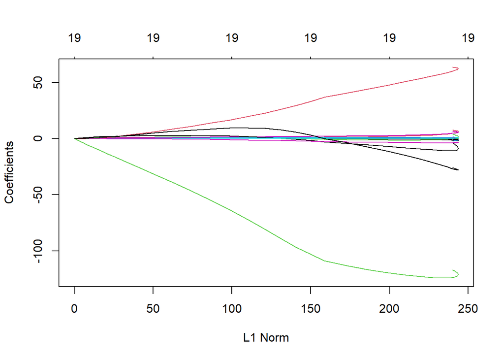

```r
plot(ridge_mod)    # wykres współczynników
```

Spodziewamy się, że oszacowania współczynników będą znacznie mniejsze, w sensie normy $l_2$, gdy używana jest duża wartość $\lambda$, w porównaniu z małą wartością $\lambda$.

Oto współczynniki, gdy $\lambda = 11498$, wraz z ich normą $l_2$:

```r
ridge_mod$lambda[50] # Wyświetl 50-tą wartość lambdy
```

```
## [1] 11497.57
```

```r
coef(ridge_mod)[,50] # Wyświetl współczynniki związane z 50-tą wartością lambdy
```

```
##   (Intercept)         AtBat          Hits         HmRun          Runs
## 407.356050200   0.036957182   0.138180344   0.524629976   0.230701523
##           RBI         Walks         Years        CAtBat         CHits
##   0.239841459   0.289618741   1.107702929   0.003131815   0.011653637
##        CHmRun         CRuns          CRBI        CWalks       LeagueN
##   0.087545670   0.023379882   0.024138320   0.025015421   0.085028114
##     DivisionW       PutOuts       Assists        Errors    NewLeagueN
##  -6.215440973   0.016482577   0.002612988  -0.020502690   0.301433531
```

```r
sqrt(sum(coef(ridge_mod)[-1,50]^2)) # Oblicz normę l2
```

```
## [1] 6.360612
```

Dla kontrastu, oto współczynniki, gdy $\lambda = 705$, wraz z ich $l_2$ normą. Zwróć uwagę na znacznie większą normę $l_2$ współczynników związanych z tą mniejszą wartością $\lambda$.

```r
ridge_mod$lambda[60] # Wyświetl 60-tą wartość lambdy
```

```
## [1] 705.4802
```

```r
coef(ridge_mod)[,60] # Wyświetl współczynniki powiązane z 60-tą wartość lambdy
```

```
##  (Intercept)        AtBat         Hits        HmRun         Runs          RBI
##  54.32519950   0.11211115   0.65622409   1.17980910   0.93769713   0.84718546
##        Walks        Years       CAtBat        CHits       CHmRun        CRuns
##   1.31987948   2.59640425   0.01083413   0.04674557   0.33777318   0.09355528
##         CRBI       CWalks      LeagueN    DivisionW      PutOuts      Assists
##   0.09780402   0.07189612  13.68370191 -54.65877750   0.11852289   0.01606037
##       Errors   NewLeagueN
##  -0.70358655   8.61181213
```

```r
sqrt(sum(coef(ridge_mod)[-1,60]^2)) # Oblicz normę l2
```

```
## [1] 57.11001
```

Funkcję `predict()` możemy wykorzystać do wielu celów. Na przykład, możemy uzyskać współczynniki regresji grzbietowej dla nowej wartości $\lambda$, powiedzmy 50:

```r
predict(ridge_mod, s = 50, type = "coefficients")[1:20,]
```

```
##   (Intercept)         AtBat          Hits         HmRun          Runs
##  4.876610e+01 -3.580999e-01  1.969359e+00 -1.278248e+00  1.145892e+00
##           RBI         Walks         Years        CAtBat         CHits
##  8.038292e-01  2.716186e+00 -6.218319e+00  5.447837e-03  1.064895e-01
##        CHmRun         CRuns          CRBI        CWalks       LeagueN
##  6.244860e-01  2.214985e-01  2.186914e-01 -1.500245e-01  4.592589e+01
##     DivisionW       PutOuts       Assists        Errors    NewLeagueN
## -1.182011e+02  2.502322e-01  1.215665e-01 -3.278600e+00 -9.496680e+00
```

Podzielimy teraz próbki na zbiór treningowy i testowy w celu oszacować błąd testu regresji grzbietowej i lasso.

```r
set.seed(1)

train = Hitters %>%
  sample_frac(0.5)

test = Hitters %>%
  setdiff(train)

x_train = model.matrix(Salary~., train)[,-1]
x_test = model.matrix(Salary~., test)[,-1]

y_train = train %>%
  select(Salary) %>%
  unlist() %>%
  as.numeric()

y_test = test %>%
  select(Salary) %>%
  unlist() %>%
  as.numeric()
```

Następnie dopasowujemy model regresji grzbietowej na zbiorze treningowym i oceniamy jego MSE na zbiorze testowym, używając $\lambda = 4$. Zwróć uwagę na użycie funkcji `predict()`. Ponownie: tym razem otrzymujemy przewidywania dla zbioru testowego, zastępując `type="coefficients"` argumentem `newx`.

```r
ridge_mod = glmnet(x_train, y_train, alpha=0, lambda = grid, thresh = 1e-12)
ridge_pred = predict(ridge_mod, s = 4, newx = x_test)
mean((ridge_pred - y_test)^2)
```

```
## [1] 139858.6
```

Testowe MSE wynosi 139858. Zauważ, że gdybyśmy zamiast tego dopasowali po prostu model tylko z wyrazem wolnym, przewidywalibyśmy każdą obserwację testową używając średniej z obserwacji zbioru treningowego. W takim przypadku moglibyśmy obliczyć MSE zestawu testowego w ten sposób:

```r
mean((mean(y_train) - y_test)^2)
```

```
## [1] 224692.1
```

Moglibyśmy również uzyskać ten sam wynik, dopasowując model regresji grzbietowej z bardzo dużą wartością $\lambda$. Zauważ, że `1e10` oznacza $10^{10}$.

```r
ridge_pred = predict(ridge_mod, s = 1e10, newx = x_test)
mean((ridge_pred - y_test)^2)
```

```
## [1] 224692.1
```

Tak więc dopasowanie modelu regresji grzbietowej z $\lambda = 4$ prowadzi do znacznie niższego testu MSE niż dopasowanie modelu z samym przechwytem.

Sprawdzimy teraz, czy jest jakaś korzyść z wykonania regresji grzbietowej z $\lambda = 4$ zamiast po prostu wykonać regresję najmniejszych kwadratów.

Przypomnijmy, że najmniejsza kwadratura to po prostu regresja grzbietowa z $\lambda = 0$.

```r
ridge_pred = predict(ridge_mod, s = 0, newx = x_test)
mean((ridge_pred - y_test)^2)
```

```
## [1] 174060
```

```r
lm(Salary~., data = train)
```

```
##
## Call:
## lm(formula = Salary ~ ., data = train)
##
## Coefficients:
## (Intercept)        AtBat         Hits        HmRun         Runs          RBI
##   2.398e+02   -1.639e-03   -2.179e+00    6.337e+00    7.139e-01    8.735e-01
##       Walks        Years       CAtBat        CHits       CHmRun        CRuns
##   3.594e+00   -1.309e+01   -7.136e-01    3.316e+00    3.407e+00   -5.671e-01
##        CRBI       CWalks      LeagueN    DivisionW      PutOuts      Assists
##  -7.525e-01    2.347e-01    1.322e+02   -1.346e+02    2.099e-01    6.229e-01
##      Errors   NewLeagueN
##  -4.616e+00   -8.330e+01
```

```r
predict(ridge_mod, s = 0, type="coefficients")[1:20,]
```

```
##   (Intercept)         AtBat          Hits         HmRun          Runs
##  239.89368111   -0.01946204   -2.07305757    6.44254692    0.64610179
##           RBI         Walks         Years        CAtBat         CHits
##    0.82179888    3.62448842  -13.28142313   -0.70314292    3.26064805
##        CHmRun         CRuns          CRBI        CWalks       LeagueN
##    3.33170237   -0.54000590   -0.72015101    0.22582579  131.41324242
##     DivisionW       PutOuts       Assists        Errors    NewLeagueN
## -134.76073238    0.20949301    0.61942855   -4.58545824  -82.35090554
```

Wygląda na to, że rzeczywiście poprawiamy się w stosunku do zwykłego najmniejszego kwadratu!

Uwaga: ogólnie, jeśli chcemy dopasować (niespenalizowany) model najmniejszych kwadratów, to powinniśmy użyć funkcji `lm()`, ponieważ ta funkcja dostarcza bardziej użytecznych wyjścia, takie jak błędy standardowe i wartości $p$ dla współczynników.

Zamiast arbitralnie wybierać $\lambda = 4$, lepiej byłoby użyć walidacji krzyżowej do wyboru parametru dostrojenia $\lambda$. Możemy to zrobić używając wbudowanej funkcji walidacji krzyżowej, `cv.glmnet()`. Domyślnie funkcja ta wykonuje 10-krotną walidację krzyżową, choć można to zmienić używając argumentu argumentu `folds`. Zauważ, że najpierw ustawiamy losowe ziarno, aby nasze wyniki były powtarzalne, ponieważ wybór krotności walidacji krzyżowej jest losowy.

```r
set.seed(1)
cv.out = cv.glmnet(x_train, y_train, alpha = 0) # Dopasuj model regresji grzbietowej na danych treningowych
lambdab = cv.out$lambda.min  # Wybierz lamdę, która minimalizuje treningowy MSE
lambdab
```

```
## [1] 326.1406
```

Widzimy zatem, że wartość $\lambda$, która powoduje najmniejszy błąd walidacji krzyżowej to 326. Możemy również wykreślić MSE jako funkcję $\lambda$:

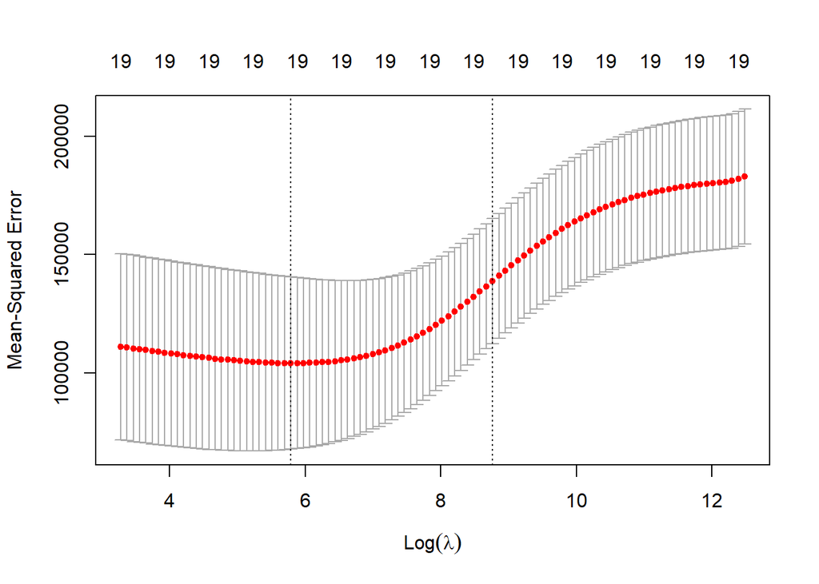

```r
plot(cv.out) # Narysuj wykres treningowego MSE jako funkcję lambda
```

Jaki jest testowy MSE związany z tą wartością $\lambda$?

```r
ridge_pred = predict(ridge_mod, s = lambdab, newx = x_test) # Użyj najlepszej lambdy do przewidywania danych testowych
mean((ridge_pred - y_test)^2) # Oblicz testowe MSE
```

```
## [1] 140056.2
```

```r
out = glmnet(x, y, alpha = 0) # Dopasuj model regresji grzbietowej do pełnego zbioru danych
predict(out, type = "coefficients", s = lambdab)[1:20,] # Wyświetlanie współczynników przy użyciu lambda wybranego przez CV
```

```
##  (Intercept)        AtBat         Hits        HmRun         Runs          RBI
##  15.44834992   0.07716945   0.85906253   0.60120338   1.06366687   0.87936073
##        Walks        Years       CAtBat        CHits       CHmRun        CRuns
##   1.62437580   1.35296285   0.01134998   0.05746377   0.40678422   0.11455696
##         CRBI       CWalks      LeagueN    DivisionW      PutOuts      Assists
##   0.12115916   0.05299953  22.08942756 -79.03490992   0.16618830   0.02941513
##       Errors   NewLeagueN
##  -1.36075645   9.12528397
```

Zgodnie z oczekiwaniami, żaden ze współczynników nie jest dokładnie zerowy - regresja grzbietowa nie dokonuje selekcji zmiennych!

## Regresja Lasso

### Wprowadzenie

Zamiast regularyzacji $L_2$, LASSO używa penalizacji $L_1$, to znaczy:

$$\min_{\beta \in \mathbb{R}^p} \sum_{i=1}^n (y_i - x_i^\top \beta)^2 +
\lambda \|\beta\|_1.$$

Ze względu na charakter normy $L_1$, LASSO ma tendencję do dawania bardziej rzadkich rozwiązań niż regresja grzbietowa. Jest to typowo użyteczne w ustawieniach wielowymiarowych, gdy prawdziwy model jest w rzeczywistości niskowymiarowym osadzeniem.

Model regresji lasso został pierwotnie opracowany w 1989 roku. Jest to alternatywa dla klasycznego oszacowania metodą najmniejszych kwadratów, która unika wielu problemów z nadmiernym dopasowaniem (**overfittingiem**), gdy mamy dużą liczbę niezależnych zmiennych.

Regresja Lasso (Least Absolute Shrinkage and Selection Operator) to technika regresji liniowej stosowana do oszacowania współczynników modelu, która wprowadza regularyzację $L_1$. Regularyzacja L1 polega na dodaniu do funkcji celu kary proporcjonalnej do wartości bezwzględnej współczynników regresji.

Regresja Lasso ma zdolność do jednoczesnego wykonania selekcji cech i regularyzacji, co oznacza, że może pomóc w identyfikacji najbardziej istotnych cech modelu, a także zmniejszyć wpływ mniej istotnych cech.

Podstawowym celem regresji Lasso jest minimalizacja funkcji celu, która składa się z dwóch składników: błędu dopasowania (sumy kwadratów różnic pomiędzy rzeczywistymi wartościami odpowiedzi a przewidywanymi wartościami modelu) i kary regularyzacyjnej $L_1$.

Wzór funkcji celu dla regresji Lasso może być przedstawiony jako: Minimize: RSS + $\lambda \|\beta\|_1$, gdzie:

- RSS to suma kwadratów różnic pomiędzy rzeczywistymi wartościami odpowiedzi a przewidywanymi wartościami modelu (błąd dopasowania),
- $\lambda$ (lambda) to parametr regularyzacji, który kontroluje siłę regularyzacji, a $\|\beta\|_1$ to norma $L_1$ współczynników regresji.

Dodanie kary regularyzacyjnej $L_1$ powoduje, że niektóre współczynniki regresji stają się równe zero, co prowadzi do selekcji cech. Im większa wartość $\lambda$, tym większa jest tendencja do redukcji współczynników do zera, prowadząc do bardziej rzadkiego modelu z mniejszą liczbą cech.

Regresja Lasso jest przydatna w przypadkach, gdy mamy do czynienia z wieloma cechami, z których niektóre mogą być nieistotne. Może pomóc w identyfikacji istotnych cech, redukcji nadmiaru danych i zwiększeniu interpretowalności modelu.

### Przykład

Zobaczyliśmy, że regresja grzbietowa z mądrym wyborem $\lambda$ może przewyższać metodę najmniejszych kwadratów, jak również model zerowy na zbiorze danych Hitters.

Teraz zobaczmy, czy lasso może dać albo dokładniejszy, albo bardziej interpretowalny model niż regresja grzbietowa.

W celu dopasowania modelu lasso, po raz kolejny używamy funkcji `glmnet()`, jednak tym razem używamy argumentu `alpha=1`. Poza tą zmianą postępujemy tak samo jak w przypadku dopasowywania modelu regresji grzbietowej:

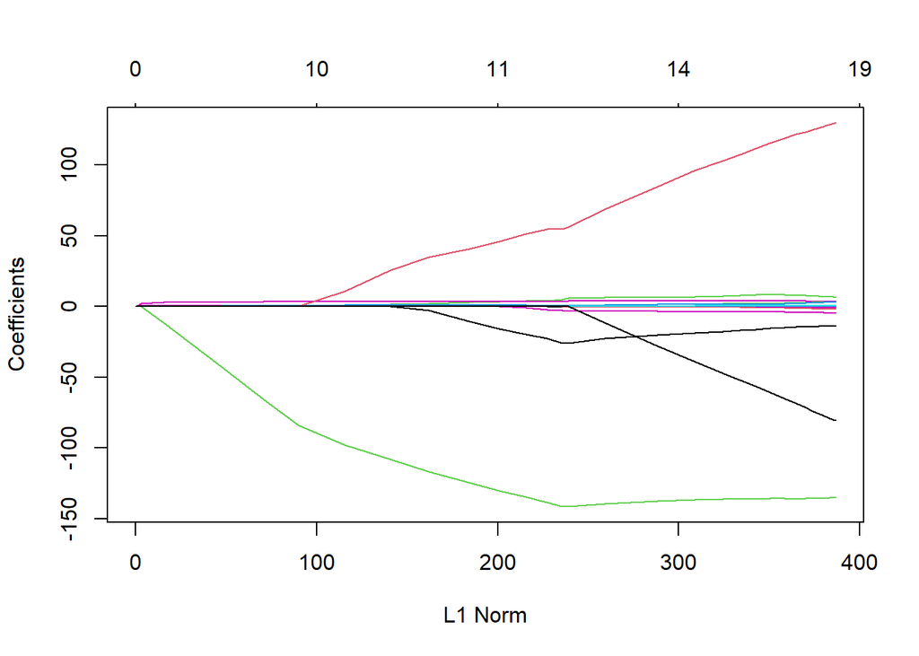

```r
lasso_mod = glmnet(x_train,
                   y_train,
                   alpha = 1,
                   lambda = grid) # Dopasuj model lasso do danych treningowych

plot(lasso_mod)    # Wykreśl współczynniki
```

Zauważmy, że na wykresie współczynników, w zależności od wyboru dostrojenia parametru, niektóre ze współczynników są dokładnie równe zeru. Teraz przeprowadzimy walidację krzyżową i obliczymy związany z nią błąd testu:

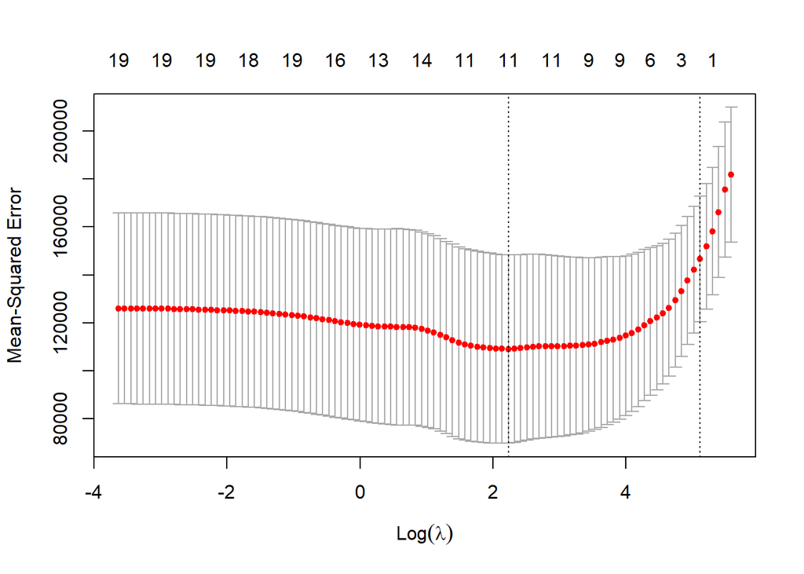

```r
set.seed(1)
cv.out = cv.glmnet(x_train, y_train, alpha = 1) # Dopasuj model lasso do danych treningowych
plot(cv.out) # Narysuj wykres MSE dla próby uczącej jako funkcję lambda
```

```r
lambdab = cv.out$lambda.min # Wybierz lamdę, która minimalizuje MSE w próbie uczącej
lasso_pred = predict(lasso_mod, s = lambdab, newx = x_test) # Użyj najlepszej lambdy do przewidywania danych testowych
mean((lasso_pred - y_test)^2) # Oblicz MSE w próbie testowej
```

```
## [1] 143273
```

Jest to znacznie niższe MSE zbioru testowego niż modelu zerowego i modelu najmniejszych kwadratów, i bardzo podobny do MSE testu regresji grzbietowej z $\lambda$ wybranej przez walidację krzyżową.

```r
out = glmnet(x, y, alpha = 1, lambda = grid) # Dopasuj model lasso do pełnego zbioru danych
lasso_coef = predict(out, type = "coefficients", s = lambdab)[1:20,] # Wyświetlanie współczynników przy użyciu lambda wybranego przez CV
lasso_coef
```

```
##   (Intercept)         AtBat          Hits         HmRun          Runs
##    1.27429897   -0.05490834    2.18012455    0.00000000    0.00000000
##           RBI         Walks         Years        CAtBat         CHits
##    0.00000000    2.29189433   -0.33767315    0.00000000    0.00000000
##        CHmRun         CRuns          CRBI        CWalks       LeagueN
##    0.02822467    0.21627609    0.41713051    0.00000000   20.28190194
##     DivisionW       PutOuts       Assists        Errors    NewLeagueN
## -116.16524424    0.23751978    0.00000000   -0.85604181    0.00000000
```

```r
lasso_coef[lasso_coef != 0] # Wyświetlanie tylko niezerowych współczynników
```

```
##   (Intercept)         AtBat          Hits         Walks         Years
##    1.27429897   -0.05490834    2.18012455    2.29189433   -0.33767315
##        CHmRun         CRuns          CRBI       LeagueN     DivisionW
##    0.02822467    0.21627609    0.41713051   20.28190194 -116.16524424
##       PutOuts        Errors
##    0.23751978   -0.85604181
```

# Twoja kolej!

Teraz nadszedł czas na przetestowanie tych metod (regresja grzbietowa i lasso) oraz metod oceny (zestaw walidacyjny, walidacja krzyżowa) na innych zbiorach danych. Możesz pracować z zespołem nad tą częścią laboratorium.

Możesz użyć dowolnego zbioru danych zawartego w **ISLR** lub wybrać jeden z pakietów danych na Kaggle/Data World itp. (zmienna zależna musi być ciągła).

Pobierz zbiór danych i spróbuj określić optymalny zestaw parametrów, które należy użyć do jego modelowania!

Wybrano zbiór danych zawierający informacje o cenach nieruchomości. Pobrano go ze strony kaggle (https://www.kaggle.com/datasets/quantbruce/real-estate-price-prediction/data). Dataset ma następujące zmienne: `X1 transaction date`  
`X2 house age`  
`X3 distance to the nearest MRT station`  
`X4 number of convenience stores`  
`X5 latitude`  
`X6 longitude`  
`Y house price of unit area`  
Wczytujemy dane i usuwamy kolumne z numerem porządkowym.

```r
library(readr)
data <- read_csv("C:/Users/Julia/Downloads/realestate.csv")
data <- data[,-1]
```

Jako zmienna zależną wybrano cenę nieruchomości, czyli `Y house price of unit area`. Tworzymy macierz projektową.

```r
x1 = model.matrix(`Y house price of unit area`~., data)[,-1]

y1 = data %>%
  select(`Y house price of unit area`) %>%
  unlist() %>%
  as.numeric()
```

Tworzymy zbiór treningowy i testowy w proporcji 7:3.

```r
set.seed(1)

train = data %>%
  sample_frac(0.7)

test = data %>%
  setdiff(train)

x_train = model.matrix(`Y house price of unit area`~., train)[,-1]
x_test = model.matrix(`Y house price of unit area`~., test)[,-1]

y_train = train %>%
  select(`Y house price of unit area`) %>%
  unlist() %>%
  as.numeric()

y_test = test %>%
  select(`Y house price of unit area`) %>%
  unlist() %>%
  as.numeric()
```

## Regresja grzbietowa

Tworzymy siatki potencjalnych wartości parametru lambda oraz dopasowujemy model.

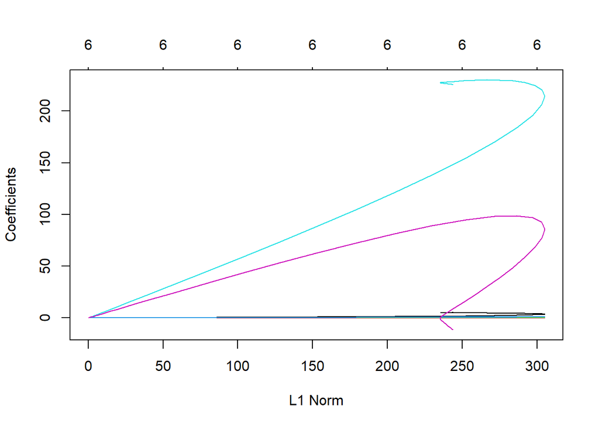

```r
grid = 10^seq(10, -2, length = 100)
ridge_mod = glmnet(x1, y1, alpha = 0, lambda = grid)
plot(ridge_mod)
```

```r
dim(coef(ridge_mod))
```

```
## [1]   7 100
```

Uzyskano macierz współczynników predyktorów o wymiarach 7 X 100.

```r
set.seed(1)
cv.out = cv.glmnet(x_train, y_train, alpha = 0)
lambdab = cv.out$lambda.min
lambdab
```

```
## [1] 1.163672
```

Wartość lambda, która powoduje najmniejszy błąd walidacji krzyżowej wynosi 1.163672.

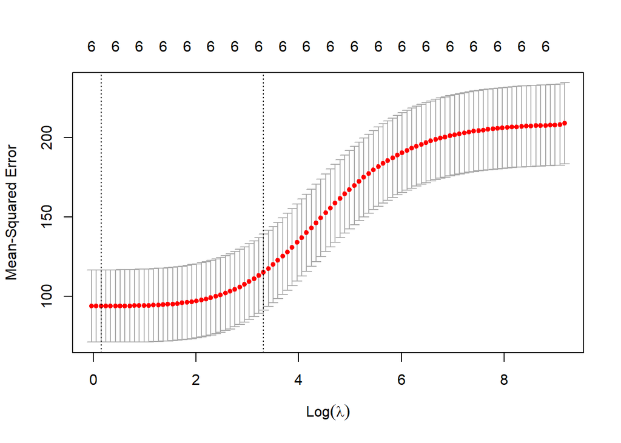

```r
plot(cv.out)
```

```r
ridge_pred = predict(ridge_mod, s = lambdab, newx = x_test)
MSE_reg_g = mean((ridge_pred - y_test)^2)
print(MSE_reg_g)
```

```
## [1] 50.43781
```

Wartość błędu MSE dla prognozy za pomocą regresji grzbietowej wynosi 50.43781

```r
out = glmnet(x1, y1, alpha = 0)
Reg_g_coef = predict(out, type = "coefficients", s = lambdab)[1:7,]
Reg_g_coef
```

```
##                              (Intercept)
##                            -1.978614e+04
##                    `X1 transaction date`
##                             4.619233e+00
##                           `X2 house age`
##                            -2.473276e-01
## `X3 distance to the nearest MRT station`
##                            -3.658812e-03
##        `X4 number of convenience stores`
##                             1.117735e+00
##                            `X5 latitude`
##                             2.300267e+02
##                           `X6 longitude`
##                             3.937311e+01
```

Żaden ze współczynników nie przyjął wartości zerowej.

## Regresja lasso

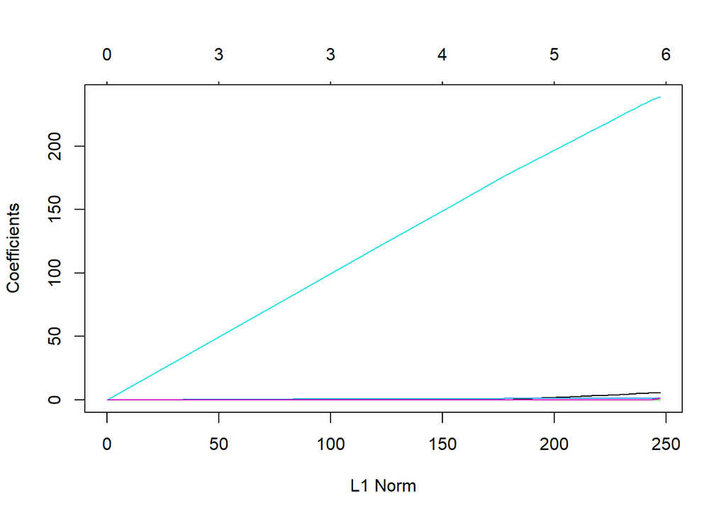

```r
lasso_mod = glmnet(x_train, y_train, alpha = 1,lambda = grid)
plot(lasso_mod)
```

```r
set.seed(1)
cv.out = cv.glmnet(x_train, y_train, alpha = 1)
lambdab = cv.out$lambda.min
lambdab
```

```
## [1] 0.1012103
```

Wartość lambda, która powoduje najmniejszy błąd walidacji krzyżowej wynosi 0.1012103.

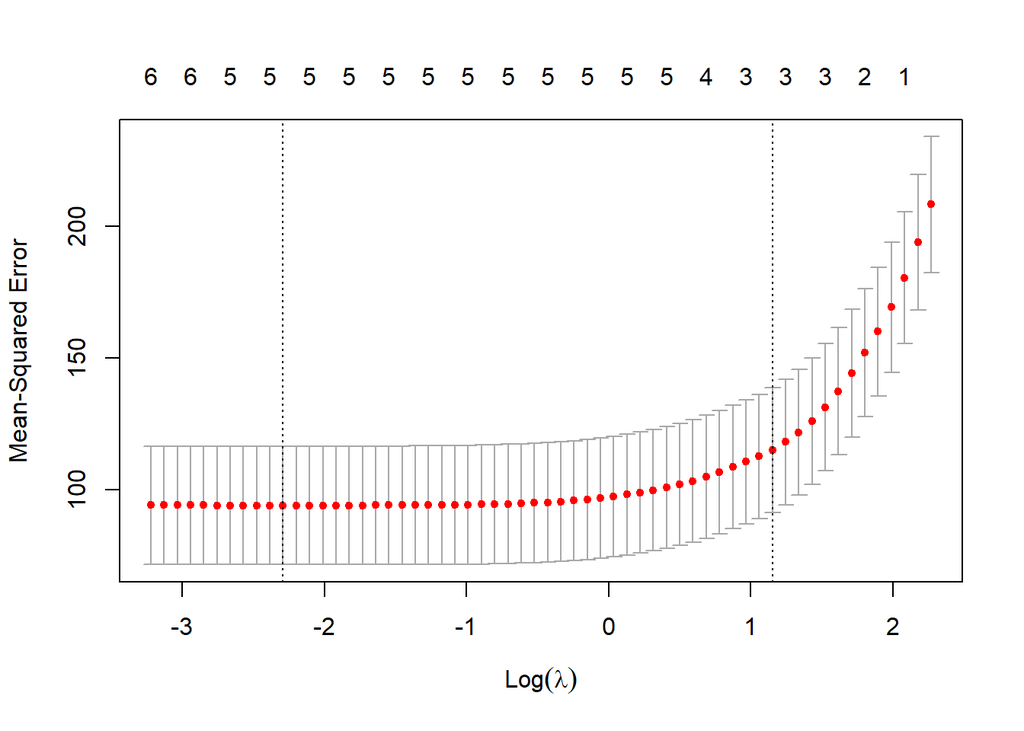

```r
plot(cv.out)
```

```r
lasso_pred = predict(lasso_mod, s = lambdab, newx = x_test)
MSE_reg_l = mean((lasso_pred - y_test)^2)
print(MSE_reg_l)
```

```
## [1] 52.97636
```

Wartość błędu MSE dla prognozy za pomocą regresji Lasso wynosi 52.97636.

```r
out = glmnet(x1, y1, alpha = 1, lambda = grid)
lasso_coef = predict(out, type = "coefficients", s = lambdab)[1:7,]
lasso_coef
```

```
##                              (Intercept)
##                            -1.511216e+04
##                    `X1 transaction date`
##                             4.770302e+00
##                           `X2 house age`
##                            -2.598753e-01
## `X3 distance to the nearest MRT station`
##                            -4.325138e-03
##        `X4 number of convenience stores`
##                             1.116139e+00
##                            `X5 latitude`
##                             2.223366e+02
##                           `X6 longitude`
##                             0.000000e+00
```

```r
lasso_coef_2 = lasso_coef[lasso_coef != 0]
lasso_coef_2
```

```
##                              (Intercept)
##                            -1.511216e+04
##                    `X1 transaction date`
##                             4.770302e+00
##                           `X2 house age`
##                            -2.598753e-01
## `X3 distance to the nearest MRT station`
##                            -4.325138e-03
##        `X4 number of convenience stores`
##                             1.116139e+00
##                            `X5 latitude`
##                             2.223366e+02
```

Jeden ze współczynników jest zerowy.

## Model OLS

```r
x_train <- as.data.frame(x_train)
y_train <- as.data.frame(y_train)
train_data <- cbind(y_train, x_train)

ols_mod <- lm(y_train ~ ., data = train_data)
summary(ols_mod)
```

```
##
## Call:
## lm(formula = y_train ~ ., data = train_data)
##
## Residuals:
##     Min      1Q  Median      3Q     Max
## -18.242  -6.168  -0.772   4.149  75.186
##
## Coefficients:
##                                                  Estimate Std. Error t value
## (Intercept)                                    -1.740e+04  9.022e+03  -1.929
## `\\`X1 transaction date\\``                     5.574e+00  1.965e+00   2.837
## `\\`X2 house age\\``                           -2.294e-01  5.013e-02  -4.575
## `\\`X3 distance to the nearest MRT station\\`` -4.357e-03  9.394e-04  -4.638
## `\\`X4 number of convenience stores\\``         1.200e+00  2.372e-01   5.059
## `\\`X5 latitude\\``                             2.395e+02  5.555e+01   4.311
## `\\`X6 longitude\\``                            2.019e+00  6.692e+01   0.030
##                                                Pr(>|t|)
## (Intercept)                                     0.05474 .
## `\\`X1 transaction date\\``                     0.00489 **
## `\\`X2 house age\\``                           7.12e-06 ***
## `\\`X3 distance to the nearest MRT station\\`` 5.37e-06 ***
## `\\`X4 number of convenience stores\\``        7.58e-07 ***
## `\\`X5 latitude\\``                            2.25e-05 ***
## `\\`X6 longitude\\``                            0.97595
## ---
## Signif. codes:  0 '***' 0.001 '**' 0.01 '*' 0.05 '.' 0.1 ' ' 1
##
## Residual standard error: 9.512 on 283 degrees of freedom
## Multiple R-squared:  0.5724, Adjusted R-squared:  0.5633
## F-statistic: 63.13 on 6 and 283 DF,  p-value: < 2.2e-16
```

```r
x_test <- as.data.frame(x_test)
ols_pred <- predict(ols_mod, newdata = x_test)
summary(ols_mod)$coefficients
```

```
##                                                     Estimate   Std. Error
## (Intercept)                                    -1.740259e+04 9.021920e+03
## `\\`X1 transaction date\\``                     5.573603e+00 1.964833e+00
## `\\`X2 house age\\``                           -2.293707e-01 5.013220e-02
## `\\`X3 distance to the nearest MRT station\\`` -4.357445e-03 9.394452e-04
## `\\`X4 number of convenience stores\\``         1.200066e+00 2.372032e-01
## `\\`X5 latitude\\``                             2.394569e+02 5.555170e+01
## `\\`X6 longitude\\``                            2.019403e+00 6.691801e+01
##                                                    t value     Pr(>|t|)
## (Intercept)                                    -1.92892270 5.474034e-02
## `\\`X1 transaction date\\``                     2.83667966 4.887771e-03
## `\\`X2 house age\\``                           -4.57531705 7.122535e-06
## `\\`X3 distance to the nearest MRT station\\`` -4.63831710 5.374225e-06
## `\\`X4 number of convenience stores\\``         5.05923268 7.583848e-07
## `\\`X5 latitude\\``                             4.31052323 2.250636e-05
## `\\`X6 longitude\\``                            0.03017728 9.759469e-01
```

```r
MSE_ols= mean((ols_pred - y_test)^2)
print(MSE_ols)
```

```
## [1] 52.98905
```

Wartość błędu MSE dla prognozy za pomocą OLS wynosi 52.98905.

Czy oczekiwałeś, że regresja grzbietowa będzie lepsza od lasso, czy odwrotnie? Jak wypada w stosunku do OLS? Pokaż odpowiednie raporty, miary dopasowania i krótko je omów (porównaj). Oczekiwano, że regresja lasso okaże się być najbardziej dopasowanym modelem jednak, to regresja grzbietowa uzyskała najniższe MSE, co oznacza, że najlepiej przewiduje wartości. Różnice pomiędzy MSE modeli są jednak niewielkie. Ponadto, to że MSE metody regresji liniowej jest trochę gorsze niż MSE regresji grzbietowej wskazuje na, to że brak regularyzacji nie powoduje mocnego pogorszenia wyników.

Które predyktory okazały się ważne w ostatecznym modelu (modelach)?